# Final Project - Retail Food Establishment Violation Severity

2025-12-10

# Overview

The Food Establishment Inspections data set, from the Boston Area Research Initiative (BARI), includes the information and findings of inspections done by the Health Division of the Department of Inspirational Services of Boston. These inspections are done by the Health Division to make sure that food establishments are keeping up to date with the health code. The data set includes information such what codes were violated, what the inspection results were, and any comments regarding the inspection. The data set has inspection violations that range from 2006 to 2024, and each record in the data set is a single violation conducted from an inspection

Looking at violation data can only uncover so much about establishments, in order to understand and realities of these places, community members much be involved to give context to the data. Conversation with Roxbury community members led to many interesting insights about their relationship with and opinion on food establishments in the neighborhood, as well as violations around the city. What was brought up among several members was how they felt about the convenience and corner stores in their neighborhood. Calling attention to the lack in quality in their meats, dairy, and produce, as well as the maintenance of the store itself. This combined with the data set showing that Roxbury is the 2nd highest neighborhood (“BRA_PD”) with the most retail establishments (~12.8% of all retail establishments), shows how interesting the community’s insights are.

With these specific establishments in mind, the measure developed from the initial food establishment inspection data set is a weighted score, based on violation level, measuring the average severity per retail establishment in a census tract.

The score reveals the average severity for the violations for the retail establishments in a given census tract in Boston. The measure could mean that there are many minor violations, or a few serious violations, or a mix. This is due to the weighted nature of the measure, where the weight of the violation increases based on how critical it is. It is important to note that this score does not distinguish between an establishment with many minor violations and an establishment with a few critical violations, a limitation to the measure. Regardless, we can still capture the average violation severity and draw some preliminary conclusions between the retail establishments in Boston census tracts.

Community members could use this measure to see how the retail establishments in their community are comparing to other communities. Also, due to the smaller nature of census tracts, they could even narrow down specific regions in the larger Blue Hill Ave area where retail establishments are producing more severe violations. This information could not only make the community aware of the status of the establishments, but could also be used to as evidence to make more systematic change with how the city health department, businesses, and the community deal with violations.

# Measure Construction

The first thing I did was do define the weights for each violation level. This was done so that in the ending score, more critical violations will have more of an impact than less critical violations. The specific weights were used to simply represent the ordering that the levels are already in, while also showing that they are an equal distance of severe from each other, instead of showing that a level might exponentially be more severe than then the tier below.

- Level 1 (weight = 1)
- Level 2 (weight = 2)
- Level 3 (weight = 3)

Now that only the relevant rows/violations are in the subset, I added a new column called “weight” that contains the weight for that record’s violation level (“viol_level”).

After applying the weight to each relevant record, I grouped the the violations by census tract (“CT_ID_20”), as that’s the aggregation level the measure is looking at comparing between.

The final set of columns in the subset, that is grouped by census tract, are the total number of violations “total_violations, the raw severity score (sum of the weighted violations in the tract)”raw_score”, the number of distinct establishments “num_establishments”, and the average severity score per establishment in the tract “normalized_score”.

In order to be able to more effectively compare the violation severity between census tracts, instead of looking at the tract specific average per establishment severity score, I added two more columns that compare the score of a tract to the mean score of the entire city “citywide_mean_retail”.The first new variable, “severity_diff”, represents the raw difference between a tract’s average violation score and the city-wide average violation score. The second, “severity_ratio”, represents the relative difference between a tract’s average violation score and the city-wide average violation score as a proportion of the city-wide mean.

# Analysis

The first thing when analyzing the data is to look at the basic overview and distribution of the average severity score per establishment in each census tract. When looking at the histogram showing the shape of the data, we can see that the data is right skewed, meaning that there are few tracts that have a large severity score, with most tracts having a score between 60 and 163 (1st quartile - 3rd quartile).

```
##    Min. 1st Qu.  Median    Mean 3rd Qu.    Max.
##     4.0    60.0   105.0   125.6   163.3   459.0
```

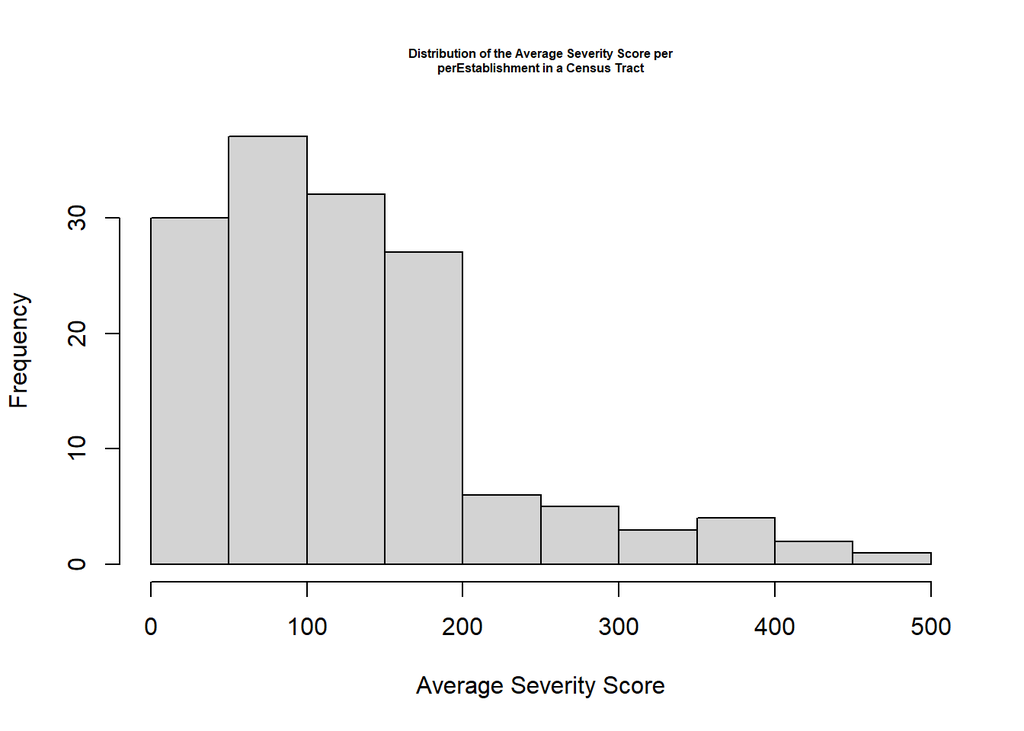

In order to better compare the scores across census tracts in Boston, we can look at the descriptive statistics of the relative difference of severity scores to the city-wide mean (“severity_ratio”). The power behind using a ratio, is that we can make proportional statements about a tract’s score relative to the citywide mean (a ratio of 1 being equal to the mean). When looking at the distribution, we can see that the median is 0.84, meaning that half of Boston’s tracts have a severity score at least 16% lower than the city-wide average. This distribution also shows a right skew, meaning that there are some tracts that are extremely high relative to the city-wide mean, the max being a tract that is 3.65 times the city-wide average.

```
##    Min. 1st Qu.  Median    Mean 3rd Qu.    Max.
## 0.03183 0.47752 0.83566 1.00000 1.29974 3.65301
```

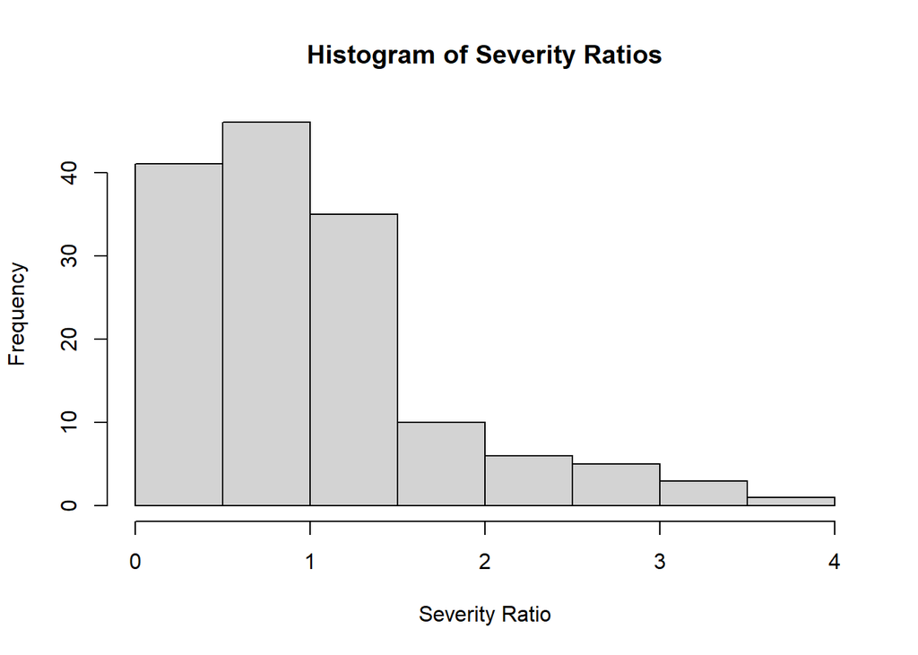

To visually see violation severity across census tracts in Boston, we can map the average severe violations per retail establishment score in each census tract relative to the city-wide score. There are pockets of tracts that have more severe violation scores for their retail establishments. Some of which are in the Blue Hill Ave area. This means that the retail establishments in these tracts are frequent and/or critical violators. It is important to note that the tracts that do not have data are due to violations being filtered out (no retail establishments, not active, or no level 1,2, or 3 violations).

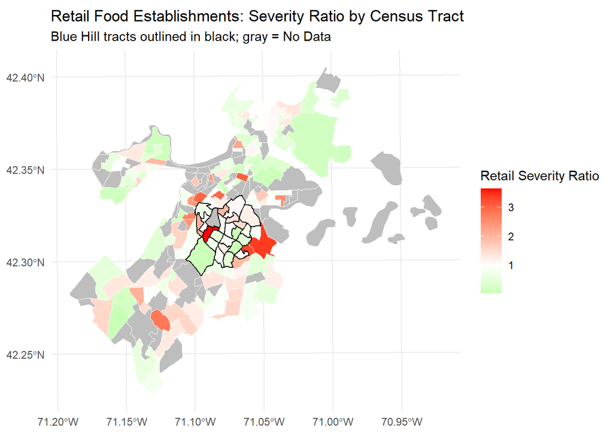

# Correlation

To see the relationship that the average severity score has with demographic data, ACS 2020 demographic data (“dem_tracts”) by census tract was merged with the severity score subset (“severity_score_retail”). Then, only a few demographic variables (Population Density, Population White, Population Black, Population Hispanic, Median Household Income, and Median Year Built) where chosen to be correlated against the average severity score per establishment in a census tract (“normalized_score”). The result was that the only significant correlations were between population White (r = -0.27, p = 0.0011), population Black (r = 0.20, p = 0.0177), and Median Household Income (r = -0.27, p = 0.0010). This means that tracts with a higher percent White population tend to have lower severity scores, tracts with a higher percent Black population tend to have higher severity scores, and lower-income tracts tend to have a higher severity score.

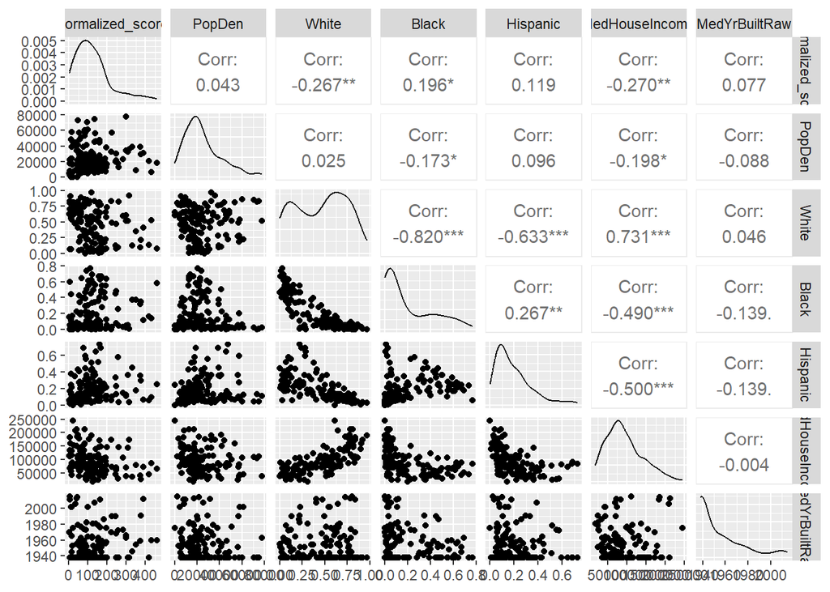

# Regression

To dig deeper into the relationship between the average violation severity score and population White, population Black, and Median Household Income, we can run a regression. The results suggest that when analyzing the three variables against the severity score, they do explain around 8% (R^2 = 0.0813, p = 0.0077 for the F-stat) of the variance. This being said, the regression also reveals that the predictor variables are not independently significant when it comes to predicting average violation severity.

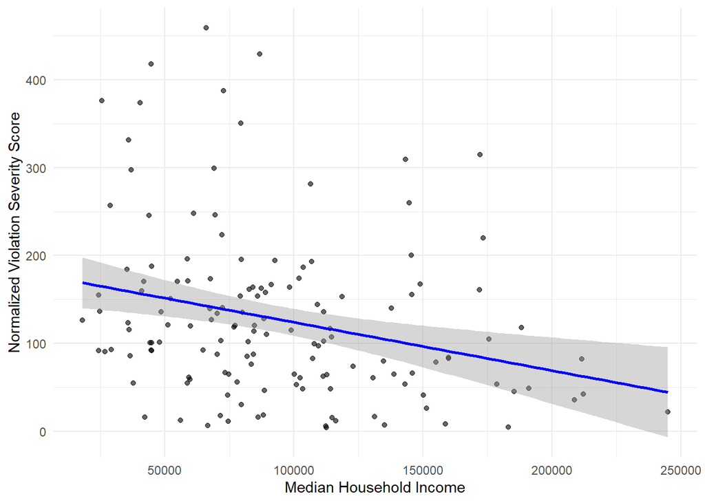

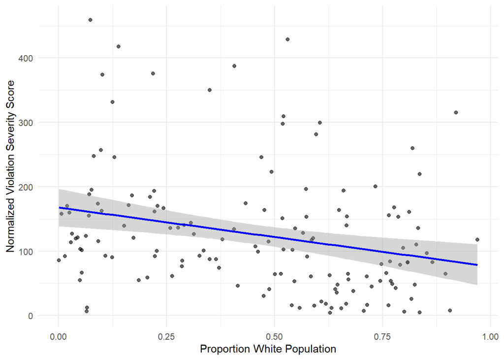

[figure not shown]

# Conclusion

In terms of the relevance of the measure to the Roxbury community, they can further investigate the retail establishments in the more severe scoring tracts. For example, when looking at the data for establishments in general in Blue Hill Ave tracts, 71.48% of violations for retail food establishments are level 1. This suggests that maybe the severe violation score for Blue Hill tracts could just mean that some establishments are chronic non-critical violators. This would change the narrative in how the city, establishments, and the community address the violations.

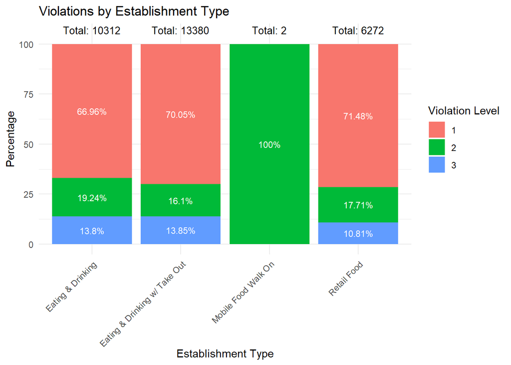

When looking at the most prominent types of level 1 violations occurring in Blue Hill Ave tracts retail establishments, they have to do with structural issues. For example, “Improper Maintenance of Floors”, “Non-Food Contact Surfaces”, and “Improper Maintenance of Walls/Ceilings”. These are non-critical violations that could be alleviated by a financial investment.

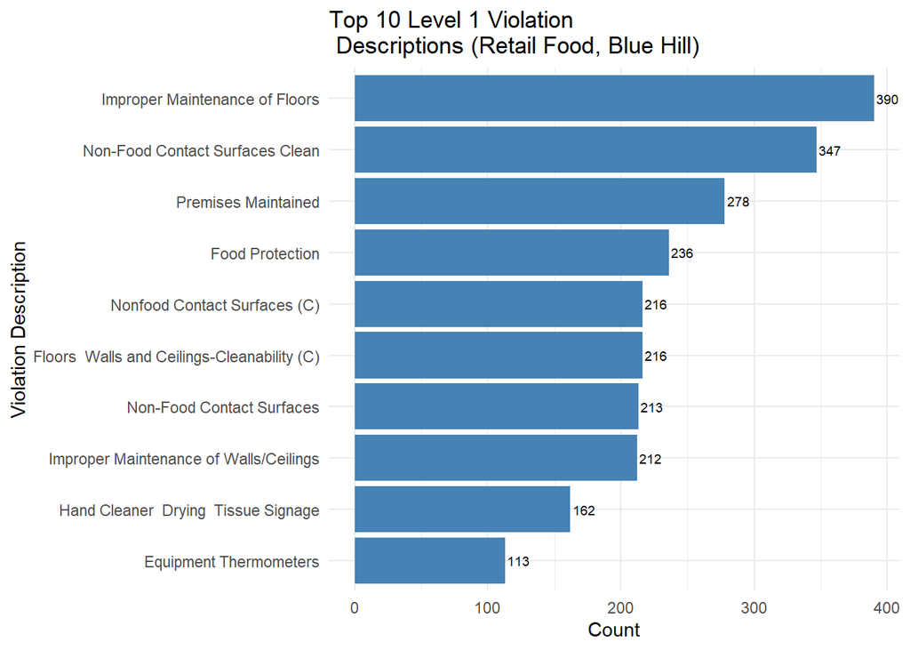

Overall, understanding the violation severity of retail establishments across Boston stemmed from the conversations and grievances given by Roxbury community members. The measure can be a starting point about what tracts or neighborhoods should be further investigated, to tease out if retail establishments are producing critical violations or if they are stacking up more non-critical violations, as the data shows for Blue Hill Ave tracts.

# Data Dictionary

## Record Level Variables from the origianl data or added to the original data:

- licstatus: The status of the license, whether active or inactive
- descript: The type of establishment
- CT_ID_20: 2020 census tracts -viol_level: Violation level of the record (e.g., 1 = minor, 3 = severe)
- licenseno: The license number of the food establishment
- violdesc: Text description of the specific violation cited during inspection
- BRA_PD: The Boston Redevelopment Authority planning district in which the establishment is located
- weight(new variable): Numeric weight assigned to the violations levels

## Census Tract Level Variables:

- total_violations: Count of all violations in tract.
- raw_score: Sum of weighted violations in tract
- num_establishments: Number of distinct retail food establishments in tract
- normalized_score: Average weighted violation score per establishment in tract
- citywide_mean_retail: Citywide average normalized score (not tract-specific)
- severity_diff: Difference between tract’s normalized score and citywide mean
- severity_ratio: Ratio of tract’s normalized score to citywide mean.
- blue_hill_outline: subset of tracts in the Blue Hill Ave region

## Demographic Variables:

- PopDen: Population Density
- White: Population White
- Black: Population Black
- Hispanic: Population Hispanic
- MedHouseIncome: Median Household Income
- MedYrBuiltRaw: Median Year Built

# Annotated R syntax

## Data Initialization

```r
library(dplyr)
library(lubridate)
library(stringr)
library(ggplot2)
library(GGally)
require(sf)
require(Hmisc)


res<-read.csv('C:/Big Data for Cities/Data project/Food_Establishment_Inspections_2006-2024.csv', na.strings=c(''))

#Geographic shapefile
shp2 <- st_read("C:/Big Data for Cities/Data project/2020_Census_Tracts_in_Boston.shp")

#ACS demograpic data, aggregated by census tract
dem <- st_read("C:/Big Data for Cities/Data project/ACS_1822_TRACT.csv")

# blue hill ave census tracts
blue_hill_tracts <- c(
  "25025980300", "25025081400", "25025080300", "25025091300", "25025082100",
  "25025091400", "25025081800", "25025090200", "25025091200", "25025091500",
  "25025091800", "25025091900", "25025091700", "25025081700", "25025081900",
  "25025090600", "25025080100", "25025081500", "25025090300", "25025082000",
  "25025090100", "25025090400", "25025090700", "25025081302"
)
```

## Measure Construction

```r
# Define weights
weights <- c("1" = 1, "2" = 2, "3" = 3)

#filter the original data set (active, retail establishments, with valid tract and violation level)
#aggregate to census tract level
#create new variables representing the violation severity for each tract
severity_score_retail <- res %>%
  filter(
    licstatus == "Active",
    descript == "Retail Food",
    !is.na(CT_ID_20),
    CT_ID_20 != "NA",
    viol_level %in% c("1","2","3")
  ) %>%
  mutate(weight = weights[viol_level]) %>%
  group_by(CT_ID_20) %>%
  summarise(
    total_violations   = n(),
    raw_score          = sum(weight, na.rm = TRUE),
    num_establishments = n_distinct(licenseno),
    normalized_score   = raw_score / num_establishments
  )

# Calculate citywide mean (retail only)
citywide_mean_retail <- mean(severity_score_retail$normalized_score, na.rm = TRUE)

# Add two columns to the subset that show the score per tract relative to the city-wide mean score
severity_score_retail <- severity_score_retail %>%
  mutate(
    severity_diff = normalized_score - citywide_mean_retail,
    severity_ratio = normalized_score / citywide_mean_retail
  )
```

## Descriptive Statistics, Histograms, Map

```r
# Descriptive statistics for the normalized score
summary(severity_score_retail$normalized_score)

# Histogram for the normalized score
hist(severity_score_retail$normalized_score,
     main = "Distribution of the Average Severity Score per Establishment in a Census Tract",
     xlab= "Average Severity Score")

# Descriptive stats for severity_ratio
summary(severity_score_retail$severity_ratio)

# Histogram for severity_ratio
hist(severity_score_retail$severity_ratio,
     main = "Histogram of Severity Ratios",
     xlab = "Severity Ratio")

#Outline for Blue Hill Ave tracts
blue_hill_outline <- shp2 %>%
  filter(geoid20 %in% blue_hill_tracts)

#Merged measure subset with the shapefile
tracts_with_scores_retail <- shp2 %>%
  left_join(severity_score_retail, by = c("geoid20" = "CT_ID_20"))

#Plot the severity ratio, no data is gray
ggplot(tracts_with_scores_retail) +
  geom_sf(aes(fill = severity_ratio), color = "white", size = 0.2) +
  geom_sf(data = blue_hill_outline, fill = NA, color = "black", size = 0.5) +
  scale_fill_gradient2(
    low = "green", mid = "white", high = "red",
    midpoint = 1,
    name = "Retail Severity Ratio",
    na.value = "gray"
  ) +

  labs(
    title = "Retail Food Establishments: Severity Ratio by Census Tract",
    subtitle = "Blue Hill tracts outlined in black; gray = No Data"
  ) +
  theme_minimal()
```

## Analysis

```r
#merge the demographic data to the tracts in the measure subset
dem_tracts <- merge(dem, severity_score_retail, by ='CT_ID_20', all.y = TRUE)

#Only select the relevant demographic variables
dem_tracts<-dem_tracts %>%
  select( 'PopDen', 'White', 'Black', 'Hispanic', 'MedHouseIncome', 'normalized_score', 'MedYrBuiltRaw')

# Convert selected columns to numeric
dem_tracts <- dem_tracts %>%
  mutate(
    PopDen = as.numeric(PopDen),
    White = as.numeric(White),
    Black = as.numeric(Black),
    Hispanic = as.numeric(Hispanic),
    MedHouseIncome = as.numeric(MedHouseIncome),
    MedYrBuiltRaw = as.numeric(MedYrBuiltRaw)
  )
#Correlation
rcorr_matrix<- dem_tracts %>%
  as.matrix() %>%
  rcorr ()

#Correlation Visual
ggpairs(dem_tracts, columns = c("normalized_score", "PopDen", "White", "Black", "Hispanic", "MedHouseIncome", "MedYrBuiltRaw"))

#regression for relevant demographic data and the normalized score
reg<- lm(normalized_score ~ MedHouseIncome + White + Black,  data = dem_tracts)

#Regression visual for Median Household Income
ggplot(dem_tracts, aes(x = MedHouseIncome, y = normalized_score)) +
  geom_point(alpha = 0.6) +
  geom_smooth(method = "lm", se = TRUE, color = "blue") +
  xlab("Median Household Income") +
  ylab("Normalized Violation Severity Score") +
  theme_minimal()

# Regression for White population and normalized_score
ggplot(dem_tracts, aes(x = White, y = normalized_score)) +
  geom_point(alpha = 0.6) +
  geom_smooth(method = "lm", se = TRUE, color = "blue") +
  xlab("Proportion White Population") +
  ylab("Normalized Violation Severity Score") +
  theme_minimal()

# Regression for Black population and  normalized_score
ggplot(dem_tracts, aes(x = Black, y = normalized_score)) +
  geom_point(alpha = 0.6) +
  geom_smooth(method = "lm", se = TRUE, color = "blue") +
  xlab("Proportion Black Population") +
  ylab("Normalized Violation Severity Score") +
  theme_minimal()
```

## Visuals Used in the Conclusion

```r
#All violations of active establishments in Blue Hill Ave census tracts
BlueHill_violations <- res %>%
  filter(CT_ID_20 %in% blue_hill_tracts, licstatus == "Active")

# Percentage of violations per establishment type
violations_per_establishment <- BlueHill_violations %>%
  filter(viol_level != "NA", viol_level != "None") %>%
  group_by(descript, viol_level) %>%
  summarise(violations = n(), .groups = "drop") %>%
  group_by(descript) %>%
  mutate(
    total = sum(violations),
    percent = round(violations / total * 100, 2)
  ) %>%
  arrange(descript, desc(violations))


#Plotting the violations by level and establishment type
ggplot(violations_per_establishment, aes(x = descript, y = percent, fill = factor(viol_level))) +
  geom_col() +
  geom_text(
    aes(label = paste0(percent, "%")),
    position = position_stack(vjust = 0.5),
    color = "white",
    size = 3
  ) +
  geom_text(
    data = violations_per_establishment %>% distinct(descript, total),
    aes(x = descript, y = 105, label = paste("Total:", total)),
    inherit.aes = FALSE,
    vjust = 0,
    size = 3.5
  ) +
  labs(
    title = "Violations by Establishment Type",
    x = "Establishment Type",
    y = "Percentage",
    fill = "Violation Level"
  ) +
  theme_minimal() +
  theme(axis.text.x = element_text(angle = 45, hjust = 1))

#all the level 1 violation descriptions ranked by count in the blue hill census tract area, for only retail establishment violations
retail_minor_violation_counts <- BlueHill_violations %>%
  filter(descript == "Retail Food", viol_level == 1) %>%
  group_by(violdesc) %>%
  summarise(count = n(), .groups = "drop") %>%
  arrange(desc(count))

retail_minor_violation_counts

# Take top 10
top10_minor_violations <- retail_minor_violation_counts %>%
  slice_max(order_by = count, n = 10)

# Plot
ggplot(top10_minor_violations, aes(x = reorder(violdesc, count), y = count)) +
  geom_col(fill = "steelblue") +
  geom_text(aes(label = count), hjust = -0.1, size = 3.5) +
  coord_flip() +
  labs(
    title = "Top 10 Level 1 Violation Descriptions (Retail Food, Blue Hill)",
    x = "Violation Description",
    y = "Count"
  ) +
  theme_minimal()
```